# Practicing with RMarkdown, Part 2

Danielle Barnas

3/3/2021

```r
knitr::opts_chunk$set(echo = TRUE, # the code will be displayed throughout doc
                      message = FALSE, # messages will not be displayed throughout doc
                      warning = FALSE, # warnings will not be displayed throughout doc
                      fig.path = "../Output/") # change figure path for all figures in doc
```

# Introduction

Today, we will use **Palmer Penguins** to manipulate figures in *RMarkdown*.  
We are using the “journal” theme.  
- Other themes can be found [here](https://www.datadreaming.org/post/r-markdown-theme-gallery/)

# Load Libraries

```r
library(tidyverse)
library(here)
library(palmerpenguins)
library(kableExtra)
library(memer) # today's totally awesome R package
```

**Figure options:**  
- out.width = “70%” - change plot size to 70% the normal size (or whatever relative size you want)  
- fig.width - figure width in “inches”  
- fig.height - figure height in “inches”  
- fig.align = “center” - location for figure in the document  
- fig.asp = 1.2 - change the aspect ratio  
- fig.cap = “some caption” - figure caption where “the caption goes in quotes”  
- fig.path = " " - because our current file is saved in Scripts, fig.path would automatically save in Scripts, but to save in a different folder, use “../Folder/” where the ../ goes up one folder in the directory.

**We can also label a code chunk by putting a name after the r and before the comma**  
- Good practice to give all our code chunks a different name  
- Can never have a repeated name, else we will get an error  
- If you are saving the figure, the code chunk name will be the name of the figure or figures.

# Make a plot

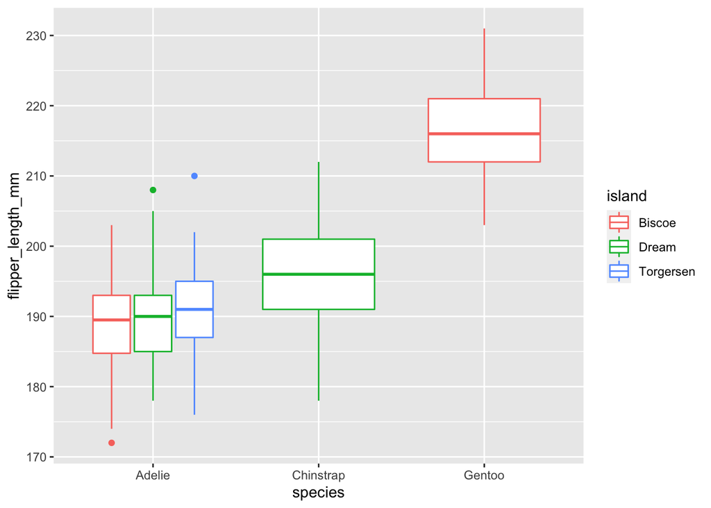

This is a figure of penguin flippers

# Make a table

| Time | Session | Topic |
| --- | --- | --- |
| *left* | *center* | *right* |
| 01:00 | 1 | Anatomy |
| 01:50 |  | *Break* |
| 02:00 | 2 | Tables |
| 02:45 |  | *Break* |

Line one contains table headers  
Line two separates table headers from table contents  
- Colon indicates alignment: left = left, left and right = center, right = right

```r
# create a crude table
penguins %>%
  group_by(species) %>%
  summarise(billmean = mean(bill_length_mm, na.rm = TRUE)) %>%
  kbl() %>%  # tidy up the table
  kable_classic() %>%  # adds nice thick lines, slightly more journal quality
  row_spec(2, # can do some specific command to a specific row (in this case, row 2)
           bold = TRUE, # bold text
           color = "white", # text color is white
           background = "red") # highlight color is red
```

| species | billmean |
| --- | --- |
| Adelie | 38.79139 |
| Chinstrap | 48.83382 |
| Gentoo | 47.50488 |

Today’s Totally Awesome R Package  
- [memer](https://github.com/sctyner/memer/)

[figure not shown]

```r
library(memer)
meme_get("DistractedBf") %>%
  meme_text_distbf("Silly R package", "BIOL 551 students", "actual coding")
```

[figure not shown]

```r
meme_get("DosEquisMan") %>%
  meme_text_top("I don't always like coding", size = 28) %>%
  meme_text_bottom("But when I do\nIt's always today's totally awesome R package", size = 18)
```